# Weight Lifting Exercise (WLE) Prediction

J. Register

3/30/2021

## SUMMARY

Key question: **Can we classify a physical exercise as “well performed” based on sensor data which tracks body movement during the execution of the exercise?**

### Approach

#### question -> input data -> features -> algorithm -> parameters -> evaluation

- An initial exploratory data analysis is conducted to identify data “tidiness” issues and potentially highly correlated independent variables.
- Derived data (variance, Standard deviation, min/max, average) with NA values are removed since it is not clear how they are calculated and imputing the values was not possible. The number of variables was reduced to 53 from 160.
- Since this is a classification prediction model, two(2) model approach are selected to be used:
  - Gradient Boosting Machine (GBM)
  - Random Forest (RF)
- The imported training dataset was split into a *training dataset* (70% of the observations) and a *test dataset* (30% of the observations)

### Cross-Validation and Training

Cross-validation will be utilized for both the GBM and RF models.

1. Split the *training* dataset into *5* smaller groups (i.e., “folds”)
2. Use *4* datasets for training and the 5th set for validation
3. Use *test* dataset for prediction

### Reference

The Weight Lifting Exercise dataset is licensed under the Creative Commons license (CC BY-SA) and was downloaded from the work done by the following research team:

Velloso, E.; Bulling, A.; Gellersen, H.; Ugulino, W.; Fuks, H. [Qualitative Activity Recognition of Weight Lifting Exercises](http://web.archive.org/web/20161224072740/http:/groupware.les.inf.puc-rio.br/work.jsf?p1=11201). Proceedings of 4th International Conference in Cooperation with SIGCHI (Augmented Human ’13) . Stuttgart, Germany: ACM SIGCHI, 2013.

## EXPLORATORY DATA ANALYSIS

Import training and testing datasets

```r
impTrain <- read.csv("https://d396qusza40orc.cloudfront.net/predmachlearn/pml-training.csv", header=TRUE)
impTest <- read.csv("https://d396qusza40orc.cloudfront.net/predmachlearn/pml-testing.csv", header=TRUE)
```

### Remove Unnecessary Columns for Model Generation

There are columns with **NA** values which appear to be derived (calculated), however, the formulas used are unknown. **The decision is to use the base sensor data for modeling**. The resulting number of variables was reduced to 53 from 160.

The structure of the resulting clean-up data set is:

```r
#
# USE A GENERALIZED FUNCTION TO APPLY TO BOTH THE TRAINING AND TEST DATASETS
#
dataPrep <- function(df) {
        cleanData <- df[-c(1:5)]
        cleanData <- cleanData[!grepl("^kurtosis_", colnames(cleanData))]
        cleanData <- cleanData[!grepl("^skewness_", colnames(cleanData))]
        cleanData <- cleanData[!grepl("^stddev_", colnames(cleanData))]
        cleanData <- cleanData[!grepl("^max_", colnames(cleanData))]
        cleanData <- cleanData[!grepl("^min_", colnames(cleanData))]
        cleanData <- cleanData[!grepl("^avg_", colnames(cleanData))]
        cleanData <- cleanData[!grepl("^var_", colnames(cleanData))]
        cleanData <- cleanData[!grepl("^max_", colnames(cleanData))]
        cleanData <- cleanData[!grepl("^amplitude_", colnames(cleanData))]
        cleanData <- cleanData[!grepl("^num_window", colnames(cleanData))]

        #  REMOVE "SUMMARY" ROWS
        cleanData <- subset(cleanData, new_window != "yes")
        cleanData <- cleanData[!grepl("^new_window", colnames(cleanData))]


        return(cleanData)
}

training <- dataPrep(impTrain)
training$classe <- as.factor(training$classe)

testing <- dataPrep(impTest)
testing$classe <- as.factor(c(""))

str(training)
```

```
## 'data.frame':    19216 obs. of  53 variables:
##  $ roll_belt           : num  1.41 1.41 1.42 1.48 1.48 1.45 1.42 1.42 1.43 1.45 ...
##  $ pitch_belt          : num  8.07 8.07 8.07 8.05 8.07 8.06 8.09 8.13 8.16 8.17 ...
##  $ yaw_belt            : num  -94.4 -94.4 -94.4 -94.4 -94.4 -94.4 -94.4 -94.4 -94.4 -94.4 ...
##  $ total_accel_belt    : int  3 3 3 3 3 3 3 3 3 3 ...
##  $ gyros_belt_x        : num  0 0.02 0 0.02 0.02 0.02 0.02 0.02 0.02 0.03 ...
##  $ gyros_belt_y        : num  0 0 0 0 0.02 0 0 0 0 0 ...
##  $ gyros_belt_z        : num  -0.02 -0.02 -0.02 -0.03 -0.02 -0.02 -0.02 -0.02 -0.02 0 ...
##  $ accel_belt_x        : int  -21 -22 -20 -22 -21 -21 -22 -22 -20 -21 ...
##  $ accel_belt_y        : int  4 4 5 3 2 4 3 4 2 4 ...
##  $ accel_belt_z        : int  22 22 23 21 24 21 21 21 24 22 ...
##  $ magnet_belt_x       : int  -3 -7 -2 -6 -6 0 -4 -2 1 -3 ...
##  $ magnet_belt_y       : int  599 608 600 604 600 603 599 603 602 609 ...
##  $ magnet_belt_z       : int  -313 -311 -305 -310 -302 -312 -311 -313 -312 -308 ...
##  $ roll_arm            : num  -128 -128 -128 -128 -128 -128 -128 -128 -128 -128 ...
```

[output cut: 39 more lines]

```r
str(testing)
```

```
## 'data.frame':    20 obs. of  54 variables:
##  $ roll_belt           : num  123 1.02 0.87 125 1.35 -5.92 1.2 0.43 0.93 114 ...
##  $ pitch_belt          : num  27 4.87 1.82 -41.6 3.33 1.59 4.44 4.15 6.72 22.4 ...
##  $ yaw_belt            : num  -4.75 -88.9 -88.5 162 -88.6 -87.7 -87.3 -88.5 -93.7 -13.1 ...
##  $ total_accel_belt    : int  20 4 5 17 3 4 4 4 4 18 ...
##  $ gyros_belt_x        : num  -0.5 -0.06 0.05 0.11 0.03 0.1 -0.06 -0.18 0.1 0.14 ...
##  $ gyros_belt_y        : num  -0.02 -0.02 0.02 0.11 0.02 0.05 0 -0.02 0 0.11 ...
##  $ gyros_belt_z        : num  -0.46 -0.07 0.03 -0.16 0 -0.13 0 -0.03 -0.02 -0.16 ...
##  $ accel_belt_x        : int  -38 -13 1 46 -8 -11 -14 -10 -15 -25 ...
##  $ accel_belt_y        : int  69 11 -1 45 4 -16 2 -2 1 63 ...
##  $ accel_belt_z        : int  -179 39 49 -156 27 38 35 42 32 -158 ...
##  $ magnet_belt_x       : int  -13 43 29 169 33 31 50 39 -6 10 ...
##  $ magnet_belt_y       : int  581 636 631 608 566 638 622 635 600 601 ...
##  $ magnet_belt_z       : int  -382 -309 -312 -304 -418 -291 -315 -305 -302 -330 ...
##  $ roll_arm            : num  40.7 0 0 -109 76.1 0 0 0 -137 -82.4 ...
```

[output cut: 40 more lines]

#### Prepare Training Datasets

The decision was made to split the *training* dataset into a *training1* (70%) and *training2* (30%) dataset for additional model testing. Model tuning (if required) will be based on results of *training2* modeling.

```r
set.seed(330)

splitRule <- trainControl(method="cv", number=5, classProbs=TRUE,
                          savePredictions="all")
## TRAINING SET IS SPLIT TO ALLOW "TUNING" BEFORE RUNNING AGAINST TEST SET
trIndx <- createDataPartition(y=training$classe,p=.70,list=FALSE)

trng1 <- training[trIndx,]
trng2test <- training[-trIndx,]

print(paste("Number of training1 observations = ", nrow(trng1)))
```

```
## [1] "Number of training1 observations =  13453"
```

```r
print(paste("Number of training2 observations = ", nrow(trng2test)))
```

```
## [1] "Number of training2 observations =  5763"
```

## Predictive Model Generation

Since this is a classification prediction model, 2 approaches were chosen to model:

- Gradient Boosting Machine (GBM)
- Random Forest

Both are run with 5-fold cross-validation. The following Kappa “Rules of Thumb” for Interpretation of baseline model:

- .81 - 1.00 Almost perfect
- .61 - .80 Substantial
- .41 - .60 Moderate
- .21 - .40 Fair
- .00 - .20 Slight
- < .00 Poor

Comparison of the model indicates that the **random forest** should be more accurate.

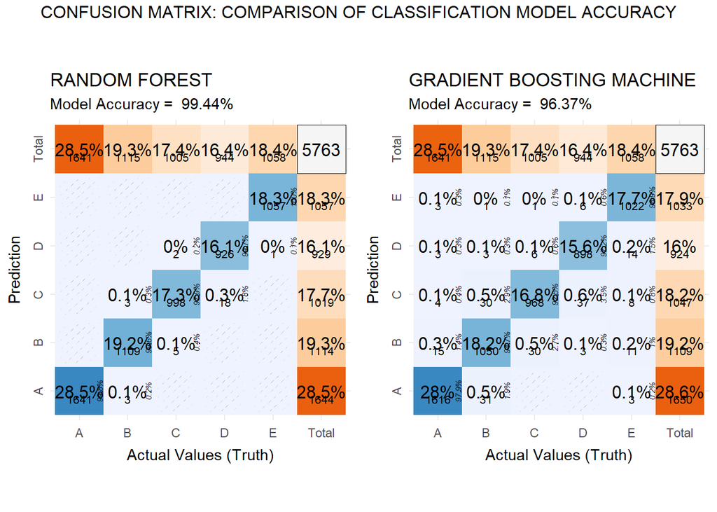

```r
splitRule <- trainControl(method="cv", number=5, classProbs=TRUE,
                          savePredictions="all")
gbmModel <- train(classe ~., data=trng1,
                  trControl=splitRule,
                  verbose=FALSE,
                  method="gbm")
predGBM <- predict(gbmModel, trng2test)

rfModel <- train(classe ~., data=trng1,
                  trControl=splitRule,
                  method="rf")
predRF <- predict(rfModel,trng2test)

cmRF <- confusion_matrix(targets=trng2test$classe,predictions=predRF)
cmGBM <- confusion_matrix(targets=trng2test$classe,predictions=predGBM)

plotRF <- plot_confusion_matrix(cmRF$'Confusion Matrix'[[1]],
                                add_sums=TRUE,
                                add_col_percentages = FALSE,
                                rotate_y_text = TRUE,
                                place_x_axis_above = FALSE,
                                font_row_percentages = font(size=2),
                                font_col_percentages = font(size=2),
                                sums_settings=sum_tile_settings(palette="Oranges",
                                                        label="Total",
                                                        tc_tile_border_color="black")) +
                ggplot2::labs(x = "Actual Values (Truth)",
                              y = "Prediction",
                              title = "RANDOM FOREST",
                              subtitle = paste("Model Accuracy = ",
                                               sprintf("%0.2f%%",round(cmRF$`Overall Accuracy`*100,digits=2))))

plotGBM <- plot_confusion_matrix(cmGBM$'Confusion Matrix'[[1]],
                                add_sums=TRUE,
                                add_col_percentages = FALSE,
                                rotate_y_text = TRUE,
                                place_x_axis_above = FALSE,
                                font_row_percentages = font(size=2),
                                font_col_percentages = font(size=2),
                                sums_settings=sum_tile_settings(palette="Oranges",
                                                        label="Total",
                                                        tc_tile_border_color="black")) +
        ggplot2::labs(x = "Actual Values (Truth)",
                              y = "Prediction",
                              title = "GRADIENT BOOSTING MACHINE",
                              subtitle = paste("Model Accuracy = ",
                                               sprintf("%0.2f%%",round(cmGBM$`Overall Accuracy`*100,digits=2))))

grid.arrange(plotRF,plotGBM, top="CONFUSION MATRIX: COMPARISON OF CLASSIFICATION MODEL ACCURACY",ncol=2)
```

**Based on model accuracy, the Random Forest model is chosen for prediction**

## Test

The Random Forest model is run against the *test* data set that was provided. The expected (predicted) results are shown below.

```r
testPrediction <- predict(rfModel,testing)
print(as.data.frame(testPrediction))
```

```
##    testPrediction
## 1               B
## 2               A
## 3               B
## 4               A
## 5               A
## 6               E
## 7               D
## 8               B
## 9               A
## 10              A
## 11              B
## 12              C
## 13              B
## 14              A
## 15              E
## 16              E
## 17              A
## 18              B
## 19              B
## 20              B
```